# 3010192 Simulación avanzada - Simulación MonteCarlo

Kevin Ferney Hidalgo Higuita (kfhidalgoh@unal.edu.co)

# 1 Configuraciones iniciales

## 1.1 Rutas

## 1.2 Librerías

[output not shown]

[output not shown]

# 2 Preparación de Datos y Distribución de Probabilidad

En este paso vamos a recrear en R la tabla de frecuencias históricas que se encuentra en la página 2 del documento. Registraremos los niveles de demanda diaria (de 0 a 10 cajas) y su frecuencia en días (sumando un total de 364 días, correspondientes a 52 semanas). A partir de esto, calcularemos la probabilidad simple (relativa) y la probabilidad acumulada para cada nivel de demanda.

1. Definir los vectores con los datos históricos extraídos del documento

```r
ventas_cajas <- 0:10
numero_dias <- c(1, 5, 12, 19, 27, 59, 74, 59, 49, 37, 22)
```

2. Crear el dataframe base con las frecuencias

```r
tabla_historica <- data.frame(
  Ventas = ventas_cajas,
  Dias = numero_dias
)
```

3. Calcular probabilidades

```r
tabla_probabilidades <- tabla_historica %>%
  # Se calcula la probabilidad simple dividiendo los días entre el total de días (364)
  mutate(Probabilidad = Dias / sum(Dias)) %>%
  # Se calcula la probabilidad acumulada usando la función cumsum()
  mutate(Prob_Acumulada = cumsum(Probabilidad)) %>%
  # Se redondean los resultados a 4 decimales para mayor claridad al visualizar
  mutate(
    Probabilidad = round(Probabilidad, 4),
    Prob_Acumulada = round(Prob_Acumulada, 4)
  )
```

4. Mostrar la tabla resultante en consola para verificar los cálculos

| Ventas | Dias | Probabilidad | Prob_Acumulada |
| --- | --- | --- | --- |
| 0 | 1 | 0.0027 | 0.0027 |
| 1 | 5 | 0.0137 | 0.0165 |
| 2 | 12 | 0.0330 | 0.0495 |
| 3 | 19 | 0.0522 | 0.1016 |
| 4 | 27 | 0.0742 | 0.1758 |
| 5 | 59 | 0.1621 | 0.3379 |
| 6 | 74 | 0.2033 | 0.5412 |
| 7 | 59 | 0.1621 | 0.7033 |
| 8 | 49 | 0.1346 | 0.8379 |
| 9 | 37 | 0.1016 | 0.9396 |
| 10 | 22 | 0.0604 | 1.0000 |

```
## Total de días históricos: 364
```

# 3 Función Generadora de Demanda

En este paso crearemos una función en R llamada generar_demanda. Esta función tomará como entrada el número de días que deseamos simular y utilizará las probabilidades calculadas en el bloque 2 para devolver valores aleatorios de demanda de leche.

1. Definir la función generadora de demanda

```r
generar_demanda <- function(n_dias, tabla_prob) {
  # n_dias: cantidad de valores de demanda a generar (ej. 7 para una semana)
  # tabla_prob: dataframe con valores de frecuencia y probabilidad acumulada

  # Generar la demanda usando muestreo aleatorio con reemplazo
  # basado en la distribución de probabilidades histórica
  demandas_simuladas <- sample(
    x = tabla_prob$Ventas,          # Posibles valores de demanda (0 a 10)
    size = n_dias,                  # Número de días a simular
    replace = TRUE,                 # Con reemplazo (los valores pueden repetirse)
    prob = tabla_prob$Probabilidad  # Vector de probabilidades simples asignadas a cada valor
  )

  # Retornar el vector con las demandas simuladas
  return(demandas_simuladas)
}
```

2. Prueba de la función para verificar su funcionamiento Fijamos una semilla para reproducibilidad en esta prueba

```r
set.seed(123)
```

Simulamos la demanda para una semana (7 días)

```r
demanda_semana_prueba <- generar_demanda(n_dias = 7, tabla_prob = tabla_probabilidades)
```

Mostramos el resultado de la prueba en consola

```
## Prueba de demanda para 7 días: 5 4 7 10 3 6 8
```

# 4 Lógica de Simulación de Inventario (Una Semana)

En este bloque construiremos la función simular_semana, la cual modela la dinámica diaria del inventario durante 7 días (de lunes a domingo). Esta función recibirá la demanda de la semana, las entregas programadas para esa semana y el inventario inicial (lo que quedó de la semana anterior). Evaluará día por día el inventario disponible, restará la demanda y calculará el inventario final y los faltantes, respetando la regla de que los faltantes no se acumulan para el día siguiente.

1. Definir la función que simula el flujo de inventario de una semana

```r
simular_semana <- function(demanda_semana, entregas_semana, inv_inicial = 0) {
  # demanda_semana: vector numérico de 7 posiciones (demanda de Lunes a Domingo)
  # entregas_semana: vector numérico de 7 posiciones (cantidad recibida cada día)
  # inv_inicial: cajas que sobraron de la semana anterior (por defecto 0)

  # Inicializar vectores para guardar los resultados diarios
  inv_final <- numeric(7)
  faltantes <- numeric(7)

  # Variable temporal para llevar el control del inventario al inicio de cada día
  inv_actual <- inv_inicial

  # Bucle iterativo para recorrer los 7 días de la semana
  for (dia in 1:7) {
    # El inventario disponible en la mañana es el actual más la entrega de ese día
    inv_disponible <- inv_actual + entregas_semana[dia]

    # Extraer la demanda específica de ese día
    demanda_hoy <- demanda_semana[dia]

    # Evaluar si la demanda supera el inventario disponible
    if (demanda_hoy > inv_disponible) {
      # Si falta leche, calculamos la cantidad faltante
      faltantes[dia] <- demanda_hoy - inv_disponible
      # El inventario final queda en 0 (los faltantes no se acumulan como inventario negativo)
      inv_actual <- 0
    } else {
      # Si hay suficiente leche, no hay faltante
      faltantes[dia] <- 0
      # El inventario se reduce según la demanda satisfecha
      inv_actual <- inv_disponible - demanda_hoy
    }

    # Registrar el inventario final de este día en el vector de resultados
    inv_final[dia] <- inv_actual
  }

  # Consolidar los resultados en un data.frame para facilitar su análisis posterior
  resultado_semana <- data.frame(
    Dia = 1:7,
    Entrega = entregas_semana,
    Demanda = demanda_semana,
    Inventario_Final = inv_final,
    Faltante = faltantes
  )

  # Retornar el dataframe con el balance semanal
  return(resultado_semana)
}
```

2. Prueba de la función con el contrato actual (30 cajas el lunes) Usamos la demanda de prueba que generamos en el Bloque 3 (o una manual para verificar)

```r
demanda_prueba <- c(5, 6, 8, 4, 7, 5, 9) # Ejemplo de demanda semanal
entregas_actuales <- c(30, 0, 0, 0, 0, 0, 0) # 30 cajas el día 1 (Lunes), 0 el resto
```

3. Ejecutar la simulación de prueba

```r
prueba_semana <- simular_semana(
  demanda_semana = demanda_prueba,
  entregas_semana = entregas_actuales,
  inv_inicial = 0
)
```

4. Mostrar el resultado en consola

| Dia | Entrega | Demanda | Inventario_Final | Faltante |
| --- | --- | --- | --- | --- |
| 1 | 30 | 5 | 25 | 0 |
| 2 | 0 | 6 | 19 | 0 |
| 3 | 0 | 8 | 11 | 0 |
| 4 | 0 | 4 | 7 | 0 |
| 5 | 0 | 7 | 0 | 0 |
| 6 | 0 | 5 | 0 | 5 |
| 7 | 0 | 9 | 0 | 9 |

# 5 Cálculo de Costos y Métricas

En este bloque vamos a crear una función llamada evaluar_semana. Esta función tomará como entrada los resultados diarios de la simulación de una semana (el dataframe generado en el Bloque 4) y calculará el costo total asociado. Sumará el costo de mantener inventario ($800 por cada caja que quede al final de cada día), calculará el costo de suministro ($15,000 fijos por cada día que haya entrega, más $100 por cada caja entregada), e identificará si ocurrió algún quiebre de stock (faltante) durante esa semana.

1. Definir la función para calcular costos y métricas de una semana

```r
evaluar_semana <- function(df_semana) {
  # df_semana: dataframe generado por la función simular_semana()

  # --- CÁLCULO DE COSTO DE INVENTARIO ---
  # Se cobra $800 por cada caja que permanezca en inventario al final del día
  total_cajas_guardadas <- sum(df_semana$Inventario_Final)
  costo_inventario <- total_cajas_guardadas * 800

  # --- CÁLCULO DE COSTO DE ENTREGA ---
  # El costo fijo de $15,000 se aplica por CADA DÍA que se reciba un pedido
  dias_con_entrega <- sum(df_semana$Entrega > 0)
  costo_fijo_entrega <- dias_con_entrega * 15000

  # El costo variable es de $100 por cada unidad recibida en la semana
  total_cajas_entregadas <- sum(df_semana$Entrega)
  costo_variable_entrega <- total_cajas_entregadas * 100

  # Costo total de entrega
  costo_entrega_total <- costo_fijo_entrega + costo_variable_entrega

  # --- CÁLCULO DEL COSTO TOTAL ---
  costo_total <- costo_inventario + costo_entrega_total

  # --- MÉTRICA DE NIVEL DE SERVICIO ---
  # Evaluamos si hubo al menos un día con faltantes en toda la semana (TRUE/FALSE)
  hubo_faltante <- any(df_semana$Faltante > 0)

  # --- INVENTARIO PARA LA PRÓXIMA SEMANA ---
  # El inventario con el que cierra el domingo (día 7)
  inv_final_domingo <- df_semana$Inventario_Final[7]

  # 2. Retornar una lista (o dataframe de 1 fila) con todas las métricas
  resultado_metricas <- data.frame(
    Costo_Inventario = costo_inventario,
    Costo_Entrega = costo_entrega_total,
    Costo_Total = costo_total,
    Hubo_Faltante = hubo_faltante,
    Inv_Traspaso = inv_final_domingo
  )

  return(resultado_metricas)
}
```

2. Prueba rápida usando el resultado del bloque anterior (prueba_semana)

```r
metricas_prueba <- evaluar_semana(prueba_semana)
```

3. Mostramos los resultados de la prueba financiera en consola

| Costo_Inventario | Costo_Entrega | Costo_Total | Hubo_Faltante | Inv_Traspaso |
| --- | --- | --- | --- | --- |
| 49600 | 18000 | 67600 | TRUE | 0 |

# 6 Motor Monte Carlo (100 Semanas)

En este bloque vamos a construir la función simular_montecarlo. Esta función encapsulará todo el proceso repetitivo: ejecutará un bucle de 100 semanas donde en cada iteración generará la demanda, simulará el inventario y evaluará los costos usando las funciones de los bloques anteriores. Además, se encargará de transferir el inventario sobrante del domingo al lunes de la siguiente semana. Al final, nos devolverá el costo total acumulado y el porcentaje de semanas que cumplieron la meta de no tener faltantes.

1. Definir el motor principal de la Simulación Monte Carlo

```r
simular_montecarlo <- function(q_lunes, q_miercoles, n_semanas = 100, tabla_prob) {
  # q_lunes: cantidad de cajas a pedir el Lunes (día 1)
  # q_miercoles: cantidad de cajas a pedir el Miércoles (día 3)
  # n_semanas: horizonte de simulación (por defecto 100 semanas)
  # tabla_prob: distribución de probabilidad de la demanda (del Bloque 2)

  # Estructurar el vector de entregas para los 7 días (L, M, X, J, V, S, D)
  entregas <- c(q_lunes, 0, q_miercoles, 0, 0, 0, 0)

  # Inicializar variables para acumular los resultados globales
  costo_total_acumulado <- 0
  semanas_con_faltantes <- 0

  # Según el problema, la simulación inicia un lunes sin inventario previo
  inv_inicial_semana <- 0

  # Bucle que recorre cada una de las semanas del horizonte de simulación
  for (semana in 1:n_semanas) {

    # Paso A: Generar la demanda aleatoria para los 7 días de esta semana
    demanda_sem <- generar_demanda(n_dias = 7, tabla_prob = tabla_prob)

    # Paso B: Simular el flujo de inventario diario con el inventario inicial correspondiente
    res_semana <- simular_semana(
      demanda_semana = demanda_sem,
      entregas_semana = entregas,
      inv_inicial = inv_inicial_semana
    )

    # Paso C: Evaluar los costos y verificar si hubo faltantes en esta semana
    metricas_sem <- evaluar_semana(res_semana)

    # Paso D: Acumular el costo total de la semana al total del horizonte
    costo_total_acumulado <- costo_total_acumulado + metricas_sem$Costo_Total

    # Si hubo algún faltante en la semana, sumar 1 al contador
    if (metricas_sem$Hubo_Faltante) {
      semanas_con_faltantes <- semanas_con_faltantes + 1
    }

    # Paso E: El inventario final del domingo pasa a ser el inicial del próximo lunes
    inv_inicial_semana <- metricas_sem$Inv_Traspaso
  }

  # Calcular el porcentaje de semanas SIN faltantes (Nivel de Servicio)
  semanas_sin_faltantes <- n_semanas - semanas_con_faltantes
  pct_sin_faltantes <- (semanas_sin_faltantes / n_semanas) * 100

  # Empaquetar el resultado final en un dataframe de una fila
  resultado_final <- data.frame(
    Q_Lunes = q_lunes,
    Q_Miercoles = q_miercoles,
    Costo_Total_100_Sem = costo_total_acumulado,
    Pct_Sin_Faltantes = pct_sin_faltantes
  )

  return(resultado_final)
}
```

2. Prueba del motor simulando el contrato actual (30 cajas solo el lunes)

```r
set.seed(42) # Fijar semilla para que el resultado sea reproducible
prueba_contrato_actual <- simular_montecarlo(
  q_lunes = 30,
  q_miercoles = 0,
  n_semanas = 100,
  tabla_prob = tabla_probabilidades
)
```

3. Mostrar el resultado de la estrategia actual

| Q_Lunes | Q_Miercoles | Costo_Total_100_Sem | Pct_Sin_Faltantes |
| --- | --- | --- | --- |
| 30 | 0 | 6594400 | 0 |

# 7 Optimización de Estrategias

En este bloque implementaremos un proceso de búsqueda exhaustiva (conocido como Grid Search). Definiremos un conjunto de posibles cantidades a pedir los lunes y los miércoles. Luego, usaremos un bucle para evaluar cada una de estas combinaciones mediante el motor de simulación (100 semanas por escenario). Finalmente, filtraremos aquellas estrategias que logren al menos un 80% de semanas sin faltantes y seleccionaremos la que minimice el costo total.

1. Definir el espacio de búsqueda (Grid Search) Sabiendo que la demanda promedio diaria es ~6.2 cajas (aprox 44 a la semana), exploramos pedidos desde 20 hasta 70 cajas en saltos de 5.

```r
posibles_lunes <- seq(20, 70, by = 5)
posibles_miercoles <- seq(0, 50, by = 5)
```

2. Crear un dataframe con todas las combinaciones posibles

```r
grid_estrategias <- expand.grid(
  Q_Lunes = posibles_lunes,
  Q_Miercoles = posibles_miercoles
)
```

3. Inicializar una lista para guardar los resultados de cada simulación

```r
resultados_simulacion <- list()
```

4. Fijar semilla global para que las comparaciones sean justas (misma demanda para todas las políticas)

```r
set.seed(2026)
```

5. Bucle para evaluar cada combinación de la cuadrícula

```r
cat("Evaluando", nrow(grid_estrategias), "estrategias. Por favor espere...\n")
```

```
## Evaluando 121 estrategias. Por favor espere...
```

```r
for (i in 1:nrow(grid_estrategias)) {
  # Extraer la cantidad de la iteración actual
  q_l_actual <- grid_estrategias$Q_Lunes[i]
  q_m_actual <- grid_estrategias$Q_Miercoles[i]

  # Ejecutar la simulación para esta combinación (100 semanas)
  # Nota: usamos la tabla de probabilidades generada en el Bloque 1
  resultado_iteracion <- simular_montecarlo(
    q_lunes = q_l_actual,
    q_miercoles = q_m_actual,
    n_semanas = 100,
    tabla_prob = tabla_probabilidades
  )

  # Guardar el dataframe resultante en la lista
  resultados_simulacion[[i]] <- resultado_iteracion
}
```

6. Consolidar todos los resultados en un único dataframe

```r
df_resultados_totales <- bind_rows(resultados_simulacion)
```

7. Filtrar y encontrar la estrategia óptima

```r
analisis_optimo <- df_resultados_totales %>%
  # Regla de negocio: Al menos 80% de las semanas sin faltantes
  filter(Pct_Sin_Faltantes >= 80) %>%
  # Ordenar de menor a mayor costo total
  arrange(Costo_Total_100_Sem)
```

8. Mostrar las 5 mejores estrategias viables

```
##
## Top 5 Mejores Estrategias que cumplen la meta (>= 80%):
```

| Q_Lunes | Q_Miercoles | Costo_Total_100_Sem | Pct_Sin_Faltantes |
| --- | --- | --- | --- |
| 45 | 0 | 23548400 | 86 |
| 30 | 15 | 27074800 | 97 |
| 20 | 25 | 39412400 | 97 |
| 35 | 10 | 43170000 | 98 |
| 40 | 5 | 54893200 | 97 |

```
## LA ESTRATEGIA ÓPTIMA ES:
```

```
## Pedir el Lunes: 45 cajas
```

```
## Pedir el Miércoles: 0 cajas
```

```
## Costo Total (100 sem): $ 23548400
```

```
## Nivel de Servicio: 86 %
```

# 8 Visualización de Resultados

## 8.1 GRÁFICO 1: Análisis de Estrategias (Costo vs. Nivel de Servicio)

Crear una nueva columna para clasificar las estrategias en el gráfico

```r
df_resultados_totales <- df_resultados_totales %>%
  mutate(
    Viabilidad = ifelse(Pct_Sin_Faltantes >= 80, "Cumple (>= 80%)", "No Cumple (< 80%)"),
    Es_Optima = ifelse(Costo_Total_100_Sem == min(Costo_Total_100_Sem[Pct_Sin_Faltantes >= 80]) &
                       Pct_Sin_Faltantes >= 80, "Óptima", "Otras")
  )
```

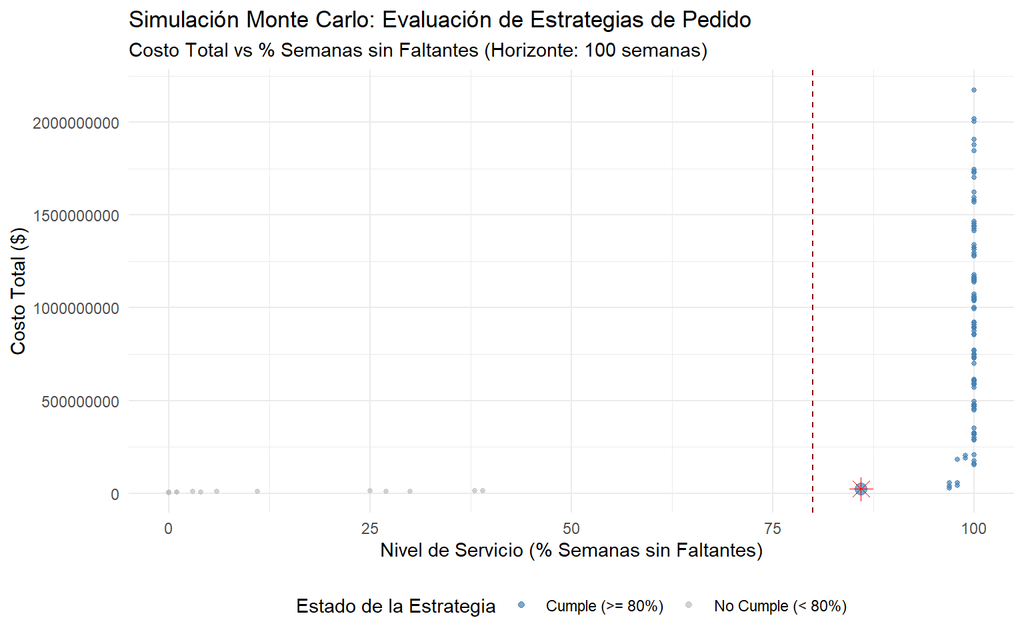

## 8.2 GRÁFICO 2: Comportamiento del Inventario (Semana Típica con Estrategia Óptima)

Extraer las cantidades óptimas del bloque 7

```r
q_lunes_opt <- estrategia_campeona$Q_Lunes
q_miercoles_opt <- estrategia_campeona$Q_Miercoles
```

Configurar entregas óptimas

```r
entregas_optimas <- c(q_lunes_opt, 0, q_miercoles_opt, 0, 0, 0, 0)
```

Generar una demanda aleatoria típica para graficar (fijamos semilla para el ejemplo)

```r
set.seed(101)
demanda_tipica <- generar_demanda(n_dias = 7, tabla_prob = tabla_probabilidades)
```

Simular esa semana con la estrategia óptima

```r
semana_grafico <- simular_semana(
  demanda_semana = demanda_tipica,
  entregas_semana = entregas_optimas,
  inv_inicial = 0
)
```

Añadir nombres de los días para el eje X

```r
semana_grafico$Nombre_Dia <- factor(
  c("Lunes", "Martes", "Miércoles", "Jueves", "Viernes", "Sábado", "Domingo"),
  levels = c("Lunes", "Martes", "Miércoles", "Jueves", "Viernes", "Sábado", "Domingo")
)
```

Crear el gráfico de barras/líneas para el inventario

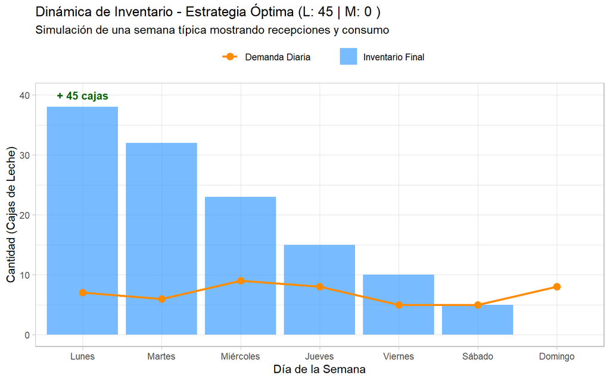